# SLW7_IEEEFraudDetection

1. Project Topic
2. Data
3. Data Cleaning
   - Data Distribution
   - Imputation
   - Removing Outliers
4. EDA and Feature Engineering
   - Time Series Features
   - Probability Encoding of Categorical Variables
5. Model
   - RandomForest
   - XG Boost
6. Conclusion and Discussion

# 1. Project Topic

This is the report of Supervised Learning for the past Kaggle competition **IEEE-CIS Fraud Detection**. The **purpose** of this project is to predict fraud from transactions with good accuracy (**auc 0.9 in kaggle private score**). I selected this project because there are some problems in data which need to be treated properly:

**Problems in the Data**

- data imbalance: only 3.5% of label is positive in train data.
- Too many features: the data has about 400 of columns
- anonymized features: columns do not have specific name.
- missing values
- correlation between features

Since the data consists of both **categorical and numerical** features, tree-based methods are appropriate. Therefore, **RandomForestClassifier** and **XG Boost** are selected.

**Data Source**

https://www.kaggle.com/competitions/ieee-fraud-detection/data

```python
import numpy as np
import pandas as pd
import matplotlib.pyplot as plt
import seaborn as sns
import math
from sklearn.model_selection import train_test_split
from sklearn import metrics
```

```python
from sklearn.ensemble import RandomForestClassifier
```

```python
sns.set_style("whitegrid")
```

# 2. Data

```python
train_tr = pd.read_parquet("data/train_transaction.parquet")
test_tr =  pd.read_parquet("data/test_transaction.parquet")
```

```python
Y = "isFraud"
ID = "TransactionID"
```

```python
Y_array = train_tr[Y].copy()
```

**Data Size**

```python
print("Number of feature is ", test_tr.shape[1])
```

```
Number of feature is  393
```

```python
n_train = train_tr.shape[0]
n_test = test_tr.shape[0]
```

```python
print("Number of row is", n_train, " in train data" )
print("Number of row is", n_test, " in test data" )
```

```
Number of row is 590540  in train data
Number of row is 506691  in test data
```

**Named features**

```python
cnames = list(train_tr.columns)
```

```python
named_X = cnames[2:17]
```

```python
train_tr[named_X].head()
```

|  | TransactionDT | TransactionAmt | ProductCD | card1 | card2 | card3 | card4 | card5 | card6 | addr1 | addr2 | dist1 | dist2 | P_emaildomain | R_emaildomain |
| --- | --- | --- | --- | --- | --- | --- | --- | --- | --- | --- | --- | --- | --- | --- | --- |
| 0 | 86400 | 68.5 | W | 13926 | NaN | 150.0 | discover | 142.0 | credit | 315.0 | 87.0 | 19.0 | NaN | None | None |
| 1 | 86401 | 29.0 | W | 2755 | 404.0 | 150.0 | mastercard | 102.0 | credit | 325.0 | 87.0 | NaN | NaN | gmail.com | None |
| 2 | 86469 | 59.0 | W | 4663 | 490.0 | 150.0 | visa | 166.0 | debit | 330.0 | 87.0 | 287.0 | NaN | outlook.com | None |
| 3 | 86499 | 50.0 | W | 18132 | 567.0 | 150.0 | mastercard | 117.0 | debit | 476.0 | 87.0 | NaN | NaN | yahoo.com | None |
| 4 | 86506 | 50.0 | H | 4497 | 514.0 | 150.0 | mastercard | 102.0 | credit | 420.0 | 87.0 | NaN | NaN | gmail.com | None |

**Anonymized features**

There are four groups of features: M, C, D, and V. M is categorical, C, D and V are numeric.

```python
cat_M = list(np.array(cnames)[list(map(lambda x: x.startswith("M"), cnames))])
numeric_C = list(np.array(cnames)[list(map(lambda x: x.startswith("C"), cnames))])
numeric_D = list(np.array(cnames)[list(map(lambda x: x.startswith("D"), cnames))])
numeric_V = list(np.array(cnames)[list(map(lambda x: x.startswith("V"), cnames))])
```

```python
train_tr[cat_M].head()
```

|  | M1 | M2 | M3 | M4 | M5 | M6 | M7 | M8 | M9 |
| --- | --- | --- | --- | --- | --- | --- | --- | --- | --- |
| 0 | T | T | T | M2 | F | T | None | None | None |
| 1 | None | None | None | M0 | T | T | None | None | None |
| 2 | T | T | T | M0 | F | F | F | F | F |
| 3 | None | None | None | M0 | T | F | None | None | None |
| 4 | None | None | None | None | None | None | None | None | None |

```python
train_tr[numeric_C].head()
```

|  | C1 | C2 | C3 | C4 | C5 | C6 | C7 | C8 | C9 | C10 | C11 | C12 | C13 | C14 |
| --- | --- | --- | --- | --- | --- | --- | --- | --- | --- | --- | --- | --- | --- | --- |
| 0 | 1.0 | 1.0 | 0.0 | 0.0 | 0.0 | 1.0 | 0.0 | 0.0 | 1.0 | 0.0 | 2.0 | 0.0 | 1.0 | 1.0 |
| 1 | 1.0 | 1.0 | 0.0 | 0.0 | 0.0 | 1.0 | 0.0 | 0.0 | 0.0 | 0.0 | 1.0 | 0.0 | 1.0 | 1.0 |
| 2 | 1.0 | 1.0 | 0.0 | 0.0 | 0.0 | 1.0 | 0.0 | 0.0 | 1.0 | 0.0 | 1.0 | 0.0 | 1.0 | 1.0 |
| 3 | 2.0 | 5.0 | 0.0 | 0.0 | 0.0 | 4.0 | 0.0 | 0.0 | 1.0 | 0.0 | 1.0 | 0.0 | 25.0 | 1.0 |
| 4 | 1.0 | 1.0 | 0.0 | 0.0 | 0.0 | 1.0 | 0.0 | 1.0 | 0.0 | 1.0 | 1.0 | 0.0 | 1.0 | 1.0 |

```python
train_tr[numeric_D].head()
```

|  | D1 | D2 | D3 | D4 | D5 | D6 | D7 | D8 | D9 | D10 | D11 | D12 | D13 | D14 | D15 |
| --- | --- | --- | --- | --- | --- | --- | --- | --- | --- | --- | --- | --- | --- | --- | --- |
| 0 | 14.0 | NaN | 13.0 | NaN | NaN | NaN | NaN | NaN | NaN | 13.0 | 13.0 | NaN | NaN | NaN | 0.0 |
| 1 | 0.0 | NaN | NaN | 0.0 | NaN | NaN | NaN | NaN | NaN | 0.0 | NaN | NaN | NaN | NaN | 0.0 |
| 2 | 0.0 | NaN | NaN | 0.0 | NaN | NaN | NaN | NaN | NaN | 0.0 | 315.0 | NaN | NaN | NaN | 315.0 |
| 3 | 112.0 | 112.0 | 0.0 | 94.0 | 0.0 | NaN | NaN | NaN | NaN | 84.0 | NaN | NaN | NaN | NaN | 111.0 |
| 4 | 0.0 | NaN | NaN | NaN | NaN | NaN | NaN | NaN | NaN | NaN | NaN | NaN | NaN | NaN | NaN |

```python
train_tr[numeric_V].head()
```

|  | V1 | V2 | V3 | V4 | V5 | V6 | V7 | V8 | V9 | V10 | ... | V330 | V331 | V332 | V333 | V334 | V335 | V336 | V337 | V338 | V339 |
| --- | --- | --- | --- | --- | --- | --- | --- | --- | --- | --- | --- | --- | --- | --- | --- | --- | --- | --- | --- | --- | --- |
| 0 | 1.0 | 1.0 | 1.0 | 1.0 | 1.0 | 1.0 | 1.0 | 1.0 | 1.0 | 0.0 | ... | NaN | NaN | NaN | NaN | NaN | NaN | NaN | NaN | NaN | NaN |
| 1 | NaN | NaN | NaN | NaN | NaN | NaN | NaN | NaN | NaN | NaN | ... | NaN | NaN | NaN | NaN | NaN | NaN | NaN | NaN | NaN | NaN |
| 2 | 1.0 | 1.0 | 1.0 | 1.0 | 1.0 | 1.0 | 1.0 | 1.0 | 1.0 | 0.0 | ... | NaN | NaN | NaN | NaN | NaN | NaN | NaN | NaN | NaN | NaN |
| 3 | NaN | NaN | NaN | NaN | NaN | NaN | NaN | NaN | NaN | NaN | ... | NaN | NaN | NaN | NaN | NaN | NaN | NaN | NaN | NaN | NaN |
| 4 | NaN | NaN | NaN | NaN | NaN | NaN | NaN | NaN | NaN | NaN | ... | 0.0 | 0.0 | 0.0 | 0.0 | 0.0 | 0.0 | 0.0 | 0.0 | 0.0 | 0.0 |

5 rows × 339 columns

# 3. Data Cleaning

## 3.1 Drop columns with NaN

It can be useful to record how many NaN exist in each row, because NaN would be a clue to predict fraud.

**Counting NaN of rows (new feature)**

```python
train_tr["SumNaN"] = np.sum(train_tr.isna(), axis = 1)
test_tr["SumNaN"] = np.sum(test_tr.isna(), axis = 1)
```

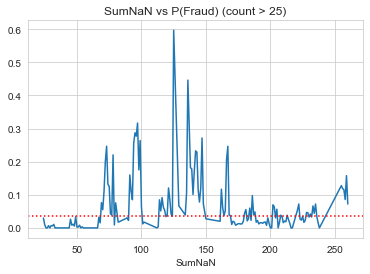

```python
fig, ax = plt.subplots()
train_tr[["SumNaN", Y]].groupby("SumNaN").agg(["count", "mean"])[Y].query("count > 25")["mean"].plot(ax = ax)
ax.set_title("SumNaN vs P(Fraud) (count > 25)")
ax.axhline(y = 0.035, ls = "dotted", color = "red", label = "0.035(overall mean)")
#ax.legend()
```

**Drop columns**

Columns in which NaN occupies more than 70% should be removed from the data.

```python
filter1 = train_tr.isna().mean() > 0.7
drop_cols = (filter1[filter1].index)

print(len(drop_cols), " features are removed")

train_tr.drop(drop_cols, axis = 1, inplace = True)
test_tr.drop(drop_cols, axis = 1, inplace = True)
```

```
168  features are removed
```

## 3.2 Data Distribution

```python
#function to plot histogram of train and test data
#y axis represent ratio of value
def ratio_x(df1, df2, select):
    Y = "TransactionID"

    n_df1 = df1.shape[0]
    df1_2 = df1[[select, Y]].groupby(select).count().rename({Y:"count"}, axis =1).sort_values("count", ascending = False).reset_index()
    df1_2["ratio"] = (df1_2["count"]/n_df1)

    n_df2 = df2.shape[0]
    df2_2 = df2[[select, Y]].groupby(select).count().rename({Y:"count"}, axis =1).sort_values("count", ascending = False).reset_index()
    df2_2["ratio"] = (df2_2["count"]/n_df1)

    fig, ax = plt.subplots(1,2, figsize = (14, 3))
    sns.barplot(data = df1_2.head(10), y = "ratio", x = select, ax = ax[0])
    sns.barplot(data = df2_2.head(10), y = "ratio", x = select, ax = ax[1])
    ax[0].set_title(select + ": ratio of top10 values (train data)")
    ax[1].set_title(select + ": ratio of top10 values (test data)")
    for i in range(2):
        ax[i].set_ylim(0, 1)
```

```python
cnames = list(train_tr.columns)
named_X = cnames[3:15]

cat_M = list(np.array(cnames)[list(map(lambda x: x.startswith("M"), cnames))])
numeric_C = list(np.array(cnames)[list(map(lambda x: x.startswith("C"), cnames))])
numeric_D = list(np.array(cnames)[list(map(lambda x: x.startswith("D"), cnames))])
numeric_V = list(np.array(cnames)[list(map(lambda x: x.startswith("V"), cnames))])
```

```python
train_tr[named_X].isna().mean()
```

```
TransactionAmt    0.000000
ProductCD         0.000000
card1             0.000000
card2             0.015127
card3             0.002650
card4             0.002670
card5             0.007212
card6             0.002660
addr1             0.111264
addr2             0.111264
dist1             0.596524
P_emaildomain     0.159949
dtype: float64
```

```python
train_tr[cat_M].isna().mean()
```

```
M1    0.459071
M2    0.459071
M3    0.459071
M4    0.476588
M5    0.593494
M6    0.286788
M7    0.586353
M8    0.586331
M9    0.586331
dtype: float64
```

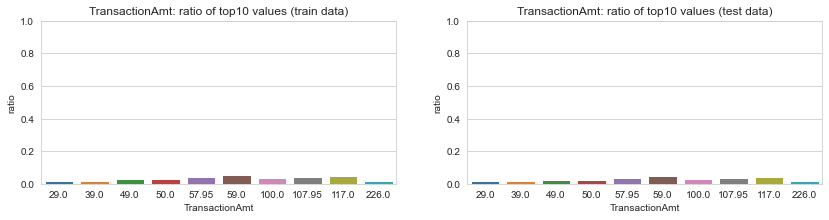

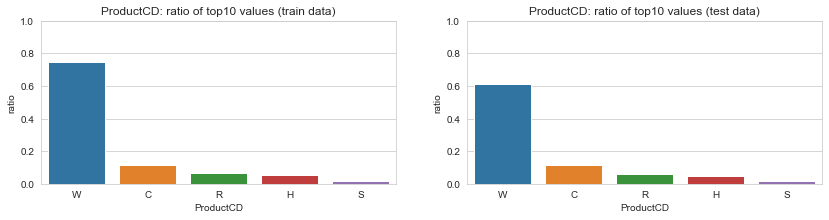

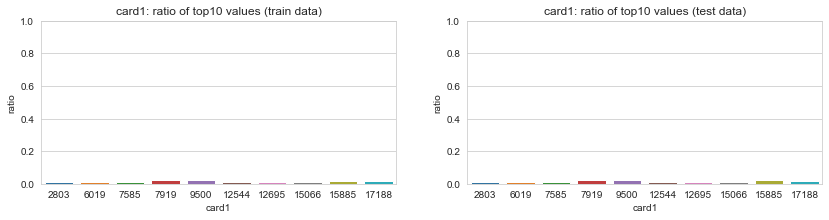

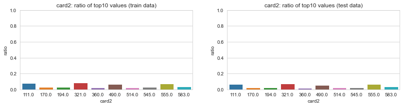

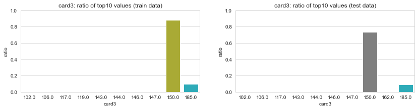

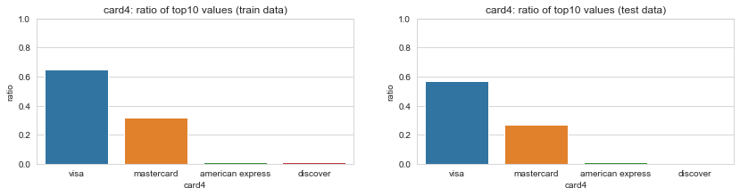

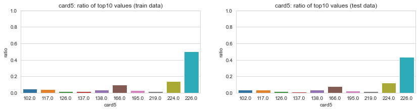

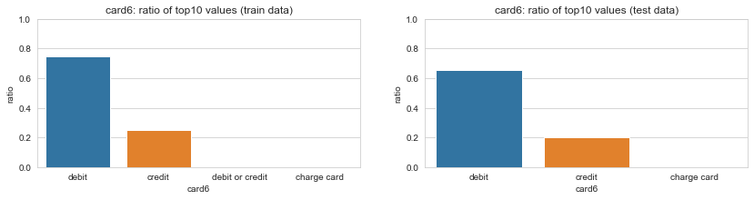

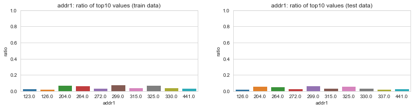

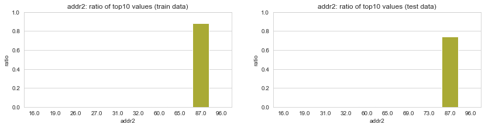

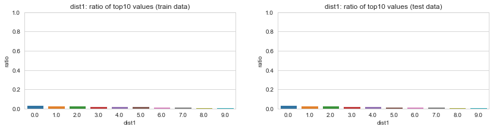

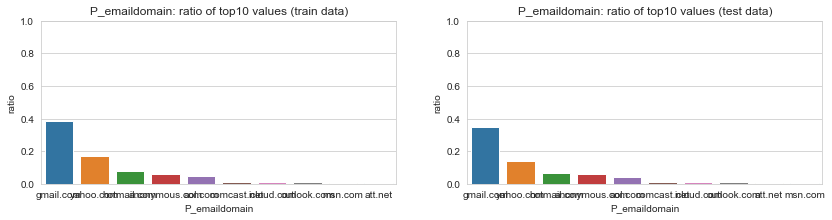

```python
for label in named_X:
    ratio_x(train_tr, test_tr, label)
```

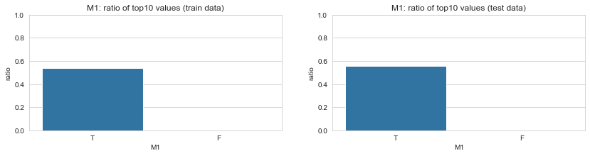

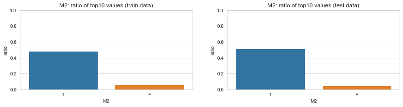

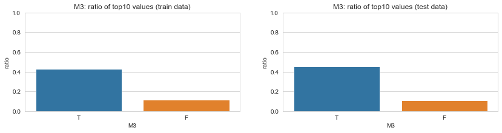

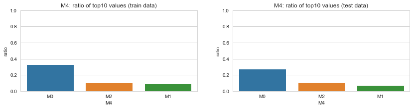

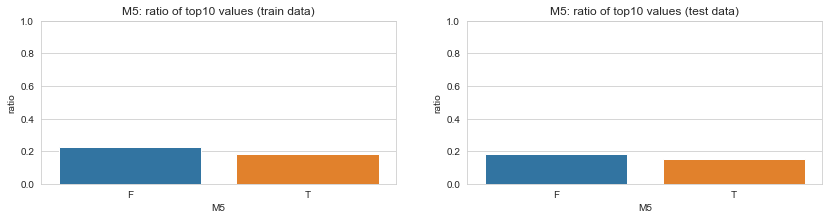

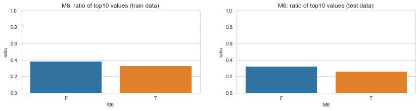

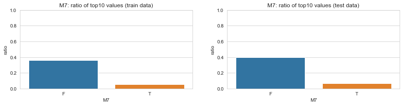

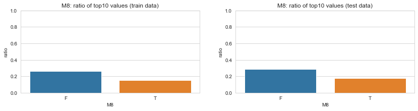

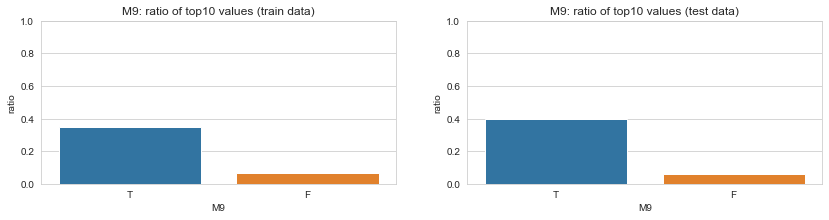

```python
for label in cat_M:
    ratio_x(train_tr, test_tr, label)
```